# ordinal31may

2024-05-31

Amalina Binti Asmail @ Ismail 22307044

Hazlienor Binti Mohd Hatta 22307055

Mohamad Afiq Amsyar Bin Hamedin 23100003

Muhammad Saufi bin Abdullah 22307048

Tiong Wen Ning 22307078

# Introduction

The dataset comprises health and lifestyle information for 200 individuals, with the key outcome variable being blood pressure (bp). The variables included are **`id`**, **`age`**, **`height`**, **`weight`**, **`cholesterol`**, **`smoke`**, and **`exercise.`** The dataset aims to investigate the relationship between blood pressure and other factors such as age, height, weight, cholesterol levels, smoking status, and exercise frequency. Understanding these relationships can help in identifying potential risk factors and lifestyle influences on blood pressure, thereby contributing to better health management and intervention strategies.

# Preparation

```r
library(here)
library(tidyverse)
library(haven)
library(gtsummary)
library(VGAM)
library(nnet)
library(broom)
library(knitr)
library(kableExtra)
```

```r
library(tibble)
library(purrr)
library(gt)
library(ggplot2)
library(ggeffects)
library(reshape2)
library(data.table)
library(ordinal)
library(foreign)
library(brant)
library(patchwork)
```

# Read data

```r
dat.o <- read_csv('hpt.csv')
summary(dat.o)
```

```
##        id              age            height          weight
##  Min.   :  4.00   Min.   :18.00   Min.   :140.0   Min.   : 50.00
##  1st Qu.: 52.75   1st Qu.:35.00   1st Qu.:155.0   1st Qu.: 68.75
##  Median :108.50   Median :48.00   Median :169.0   Median : 85.00
##  Mean   :110.64   Mean   :48.59   Mean   :169.9   Mean   : 85.23
##  3rd Qu.:167.25   3rd Qu.:62.25   3rd Qu.:186.0   3rd Qu.:101.25
##  Max.   :226.00   Max.   :79.00   Max.   :199.0   Max.   :119.00
##   cholesterol        smoke         exercise           bp
##  Min.   :150.0   Min.   :0.00   Min.   :0.000   Min.   : 91.0
##  1st Qu.:190.0   1st Qu.:0.00   1st Qu.:1.000   1st Qu.:115.0
##  Median :237.0   Median :1.00   Median :2.000   Median :139.0
##  Mean   :230.1   Mean   :0.56   Mean   :2.045   Mean   :137.1
##  3rd Qu.:266.2   3rd Qu.:1.00   3rd Qu.:3.000   3rd Qu.:160.2
##  Max.   :299.0   Max.   :1.00   Max.   :4.000   Max.   :179.0
```

```r
glimpse(dat.o)
```

```
## Rows: 200
## Columns: 8
## $ id          <dbl> 176, 51, 121, 196, 71, 199, 107, 13, 215, 25, 40, 91, 74, …
## $ age         <dbl> 32, 50, 22, 21, 63, 29, 78, 40, 31, 75, 63, 29, 74, 34, 42…
## $ height      <dbl> 182, 176, 170, 164, 192, 143, 191, 148, 196, 167, 169, 199…
## $ weight      <dbl> 53, 90, 110, 83, 78, 118, 76, 101, 103, 119, 83, 57, 57, 1…
## $ cholesterol <dbl> 268, 278, 259, 255, 290, 165, 268, 183, 290, 283, 188, 151…
## $ smoke       <dbl> 0, 1, 0, 1, 0, 1, 0, 1, 0, 1, 1, 1, 1, 1, 1, 0, 1, 0, 1, 0…
## $ exercise    <dbl> 1, 1, 1, 1, 0, 1, 2, 0, 2, 1, 4, 0, 4, 2, 2, 0, 2, 0, 2, 4…
## $ bp          <dbl> 106, 142, 170, 136, 174, 113, 105, 134, 173, 145, 117, 135…
```

We can convert those variables to factor variables:

```r
dat.o <-
  dat.o %>%
  mutate(across(where(is.labelled), ~as_factor(.x)))
summary(dat.o)
```

```
##        id              age            height          weight
##  Min.   :  4.00   Min.   :18.00   Min.   :140.0   Min.   : 50.00
##  1st Qu.: 52.75   1st Qu.:35.00   1st Qu.:155.0   1st Qu.: 68.75
##  Median :108.50   Median :48.00   Median :169.0   Median : 85.00
##  Mean   :110.64   Mean   :48.59   Mean   :169.9   Mean   : 85.23
##  3rd Qu.:167.25   3rd Qu.:62.25   3rd Qu.:186.0   3rd Qu.:101.25
##  Max.   :226.00   Max.   :79.00   Max.   :199.0   Max.   :119.00
##   cholesterol        smoke         exercise           bp
##  Min.   :150.0   Min.   :0.00   Min.   :0.000   Min.   : 91.0
##  1st Qu.:190.0   1st Qu.:0.00   1st Qu.:1.000   1st Qu.:115.0
##  Median :237.0   Median :1.00   Median :2.000   Median :139.0
##  Mean   :230.1   Mean   :0.56   Mean   :2.045   Mean   :137.1
##  3rd Qu.:266.2   3rd Qu.:1.00   3rd Qu.:3.000   3rd Qu.:160.2
##  Max.   :299.0   Max.   :1.00   Max.   :4.000   Max.   :179.0
```

We will use `cut()` function to create a categorical (factor) outcome variable. Variable bp will be categorized into a 4 category variable bp4.

```r
dat.o <- dat.o %>%
  mutate(bp4 = cut(bp,
                   breaks = c(-Inf, 120, 140, 160, Inf),
                   labels = c('=<120','121-140','141-160','>160'),
                   right = TRUE))
```

Let us check if we have grouped correctly:

```r
# Summarizing the min and max of 'bp' for each 'bp4' group
dat.o %>%
  select(bp4, bp) %>%
  group_by(bp4) %>%
  summarize(
    min_bp = min(bp, na.rm = TRUE),
    max_bp = max(bp, na.rm = TRUE)
  )
```

```
## # A tibble: 4 × 3
##   bp4     min_bp max_bp
##   <fct>    <dbl>  <dbl>
## 1 =<120       91    120
## 2 121-140    121    140
## 3 141-160    141    160
## 4 >160       161    179
```

Next, we will used ordered function to create an ordinal variable and define the levels of the variable.

We will reverse the order of the outcome variable.

```r
lev <- c('>160','141-160','121-140','=<120')
lev
```

```
## [1] ">160"    "141-160" "121-140" "=<120"
```

```r
dat.o <- dat.o %>%
  mutate(bp4a = fct_relevel(bp4, lev)) %>%
  mutate(bp4a = ordered(bp4a, levels = lev))
```

Let us check if we have done correctly:

```r
str(dat.o$bp4a)
```

```
##  Ord.factor w/ 4 levels ">160"<"141-160"<..: 4 2 1 3 1 4 4 3 1 2 ...
```

```r
levels(dat.o$bp4)
```

```
## [1] "=<120"   "121-140" "141-160" ">160"
```

```r
table(dat.o$bp4)
```

```
##
##   =<120 121-140 141-160    >160
##      66      40      44      50
```

```r
levels(dat.o$bp4a)
```

```
## [1] ">160"    "141-160" "121-140" "=<120"
```

```r
table(dat.o$bp4a)
```

```
##
##    >160 141-160 121-140   =<120
##      50      44      40      66
```

# Exploratory Data Analysis

#### **Histogram of Age by Blood Pressure Category**

```r
# Histogram of age by blood pressure category
p1 <- ggplot(dat.o, aes(x = age, fill = bp4)) +
  geom_histogram(binwidth = 5, position = "dodge", alpha = 0.7) +
  facet_wrap(~ bp4, scales = "free_y") +
  labs(title = "Distribution of Age by Blood Pressure Category",
       x = "Age",
       y = "Count",
       fill = "Blood Pressure Category") +
  theme_minimal()
```

#### **Histogram of Height by Blood Pressure Category**

```r
# Histogram of height by blood pressure category
p2 <- ggplot(dat.o, aes(x = height, fill = bp4)) +
  geom_histogram(binwidth = 5, position = "dodge", alpha = 0.7) +
  facet_wrap(~ bp4, scales = "free_y") +
  labs(title = "Distribution of Height by Blood Pressure Category",
       x = "Height",
       y = "Count",
       fill = "Blood Pressure Category") +
  theme_minimal()
```

#### **Histogram of Weight by Blood Pressure Category**

```r
# Histogram of weight by blood pressure category
p3 <- ggplot(dat.o, aes(x = weight, fill = bp4)) +
  geom_histogram(binwidth = 5, position = "dodge", alpha = 0.7) +
  facet_wrap(~ bp4, scales = "free_y") +
  labs(title = "Distribution of Weight by Blood Pressure Category",
       x = "Weight",
       y = "Count",
       fill = "Blood Pressure Category") +
  theme_minimal()
```

#### **Histogram of Cholesterol Levels by Blood Pressure Category**

```r
# Histogram of cholesterol levels by blood pressure category
p4 <- ggplot(dat.o, aes(x = cholesterol, fill = bp4)) +
  geom_histogram(binwidth = 10, position = "dodge", alpha = 0.7) +
  facet_wrap(~ bp4, scales = "free_y") +
  labs(title = "Distribution of Cholesterol Levels by Blood Pressure Category",
       x = "Cholesterol Levels",
       y = "Count",
       fill = "Blood Pressure Category") +
  theme_minimal()
```

#### **Bar Plot of Smoking Status by Blood Pressure Category**

```r
# Bar plot of smoking status by blood pressure category
p5 <- ggplot(dat.o, aes(x = bp4, fill = smoke)) +
  geom_bar(position = "dodge", alpha = 0.7) +
  labs(title = "Distribution of Smoking Status by Blood Pressure Category",
       x = "Blood Pressure Category",
       y = "Count",
       fill = "Smoking Status") +
  theme_minimal()
```

#### **Bar Plot of Exercise Frequency by Blood Pressure Category**

```r
# Bar plot of exercise frequency by blood pressure category
p6 <- ggplot(dat.o, aes(x = bp4, fill = exercise)) +
  geom_bar(position = "dodge", alpha = 0.7) +
  labs(title = "Distribution of Exercise Frequency by Blood Pressure Category",
       x = "Blood Pressure Category",
       y = "Count",
       fill = "Exercise Frequency") +
  theme_minimal()
```

[figure not shown]

```r
# Combine all plots into a single visualization
combined_plot <- (p1 + p2) / (p3 + p4) / (p5 + p6)

# Print the combined plot
print(combined_plot)
```

```r
dat.o <- dat.o %>%
  mutate(smoke = as.factor(smoke))

summary_table <- dat.o %>%
  select(bp4, age, height, weight, cholesterol, smoke, exercise) %>%
  tbl_summary(
    by = bp4,
    statistic = list(
      all_continuous() ~ "{mean} ({sd})",
      all_categorical() ~ "{n} ({p}%)"
    ),
    type = list(
      where(is.logical) ~ "categorical"
    ),
    label = list(
      age ~ "age",
      height ~ "height (cm)",
      weight ~ "weight (kg)",
      cholesterol ~ "cholesterol (mmol/L)",
      smoke ~ "smoke",
      exercise ~ "exercise"
    ),
    missing_text = "Missing"
  ) %>%
  modify_caption("**Table 1. Participant Characteristics by Blood Pressure Group**") %>%
  modify_header(label ~ "**Variable**") %>%
  modify_spanning_header(
    starts_with("stat_") ~ "**Blood Pressure Group**"
  ) %>%
  modify_footnote(all_stat_cols() ~ "Mean (SD) or Frequency (%)") %>%
  bold_labels() %>%
  as_gt()

# Print the summary table
print(summary_table)
```

[output not shown]

[output cut: 476 more lines]

[output not shown]

# Estimation

## Adjacent-category model or multinomial or baseline logit model

Here, we will show how to replicate the baseline logit model (unconstrained). We could not reproduce the adjancent-category models that is based on constrained logit models.

Generate a new variable but with no ordering

```r
dat.o <-
  dat.o %>%
  mutate(bp4b = fct_relevel(bp4, lev))
```

Run the mlogit

```r
mlogit1 <-
  vglm(bp4 ~ exercise, multinomial, data = dat.o)
summary(mlogit1)
```

```
##
## Call:
## vglm(formula = bp4 ~ exercise, family = multinomial, data = dat.o)
##
## Coefficients:
##               Estimate Std. Error z value Pr(>|z|)
## (Intercept):1  0.24174    0.32800   0.737    0.461
## (Intercept):2 -0.11212    0.36160  -0.310    0.757
## (Intercept):3 -0.20251    0.36472  -0.555    0.579
## exercise:1     0.01744    0.13094   0.133    0.894
## exercise:2    -0.05600    0.14812  -0.378    0.705
## exercise:3     0.03596    0.14449   0.249    0.803
##
## Names of linear predictors: log(mu[,1]/mu[,4]), log(mu[,2]/mu[,4]),
## log(mu[,3]/mu[,4])
##
## Residual deviance: 546.5586 on 594 degrees of freedom
##
## Log-likelihood: -273.2793 on 594 degrees of freedom
##
## Number of Fisher scoring iterations: 3
##
## No Hauck-Donner effect found in any of the estimates
##
##
## Reference group is level  4  of the response
```

```r
# Calculate confidence intervals for the model parameters
conf_intervals <- confint(mlogit1)

# Print the confidence intervals
print(conf_intervals)
```

```
##                    2.5 %    97.5 %
## (Intercept):1 -0.4011282 0.8846110
## (Intercept):2 -0.8208327 0.5965965
## (Intercept):3 -0.9173449 0.5123234
## exercise:1    -0.2391881 0.2740689
## exercise:2    -0.3463211 0.2343156
## exercise:3    -0.2472402 0.3191544
```

And get the RRR

```r
exp(coef(mlogit1))
```

```
## (Intercept):1 (Intercept):2 (Intercept):3    exercise:1    exercise:2
##     1.2734648     0.8939387     0.8166777     1.0175934     0.9455365
##    exercise:3
##     1.0366114
```

```r
# Function to calculate confidence intervals for log odds and exponentiate them for RRR
calc_ci_rrr <- function(estimate, stderr) {
  log_rrr_ci_lower <- estimate - 1.96 * stderr
  log_rrr_ci_upper <- estimate + 1.96 * stderr
  rrr_ci_lower <- exp(log_rrr_ci_lower)
  rrr_ci_upper <- exp(log_rrr_ci_upper)
  return(c(rrr_ci_lower, rrr_ci_upper))
}

# Create data frames for coefficient estimates and RRR
coefficients <- data.frame(
  Term = c("(Intercept):1", "(Intercept):2", "(Intercept):3", "exercise:1", "exercise:2", "exercise:3"),
  Estimate = c(0.24174, -0.11212, -0.20251, 0.01744, -0.05600, 0.03596),
  StdError = c(0.32800, 0.36160, 0.36472, 0.13094, 0.14812, 0.14449),
  ZValue = c(0.737, -0.310, -0.555, 0.133, -0.378, 0.249),
  PValue = c(0.461, 0.757, 0.579, 0.894, 0.705, 0.803)
)

rrr <- data.frame(
  Term = c("(Intercept):1", "(Intercept):2", "(Intercept):3", "exercise:1", "exercise:2", "exercise:3"),
  RRR = c(1.2734648, 0.8939387, 0.8166777, 1.0175934, 0.9455365, 1.0366114)
)

# Calculate CIs for RRR and combine the data frames
combined_table <- coefficients %>%
  mutate(CI_RRR = purrr::map2(Estimate, StdError, calc_ci_rrr)) %>%
  tidyr::unnest_wider(CI_RRR, names_sep = "_") %>%
  rename(CI_RRR_Lower = CI_RRR_1, CI_RRR_Upper = CI_RRR_2) %>%
  left_join(rrr, by = "Term")

# Print the combined table in a tidy format
kable(combined_table, format = "pipe", caption = "Combined Coefficients and RRR Table with Confidence Intervals")
```

Combined Coefficients and RRR Table with Confidence Intervals

| Term | Estimate | StdError | ZValue | PValue | CI_RRR_Lower | CI_RRR_Upper | RRR |
| --- | --- | --- | --- | --- | --- | --- | --- |
| (Intercept):1 | 0.24174 | 0.32800 | 0.737 | 0.461 | 0.6695563 | 2.422064 | 1.2734648 |
| (Intercept):2 | -0.11212 | 0.36160 | -0.310 | 0.757 | 0.4400548 | 1.815963 | 0.8939387 |
| (Intercept):3 | -0.20251 | 0.36472 | -0.555 | 0.579 | 0.3995720 | 1.669194 | 0.8166777 |
| exercise:1 | 0.01744 | 0.13094 | 0.133 | 0.894 | 0.7872555 | 1.315323 | 1.0175934 |
| exercise:2 | -0.05600 | 0.14812 | -0.378 | 0.705 | 0.7072895 | 1.264043 | 0.9455365 |
| exercise:3 | 0.03596 | 0.14449 | 0.249 | 0.803 | 0.7809529 | 1.375972 | 1.0366114 |

## Continuation-ratio

To perform a continuation-ratio analysis similar to the example you provided but for the **`bp4`** variable, we need to create three comparisons:

1. Compare **`bp4 == >160`** vs. **`bp4 == 141-160`**
2. Compare **`bp4 == >160 and bp4 == 141-160`** vs. **`bp4 == 121-140`**
3. Compare **`bp4 == >160 and bp4 == 141-160 and bp4 == 121-140`** vs. **`bp4 == =<120`**
   1. Compare **`bp4 == >160`** vs. **`bp4 == 141-160`**

   ```r
   table(dat.o$bp4) ; table(dat.o$bp4a)
   ```

   ```
   ##
   ##   =<120 121-140 141-160    >160
   ##      66      40      44      50
   ```

   ```
   ##
   ##    >160 141-160 121-140   =<120
   ##      50      44      40      66
   ```

```r
dat.oa <-
  dat.o %>%
  filter(bp4 == '>160' | bp4 == '141-160')
cr1 <- glm(bp4a ~ exercise, family = binomial(link ='logit'),
           data = dat.oa)
summary(cr1)
```

```
##
## Call:
## glm(formula = bp4a ~ exercise, family = binomial(link = "logit"),
##     data = dat.oa)
##
## Coefficients:
##             Estimate Std. Error z value Pr(>|z|)
## (Intercept) -0.20414    0.36742  -0.556    0.578
## exercise     0.03674    0.14607   0.252    0.801
##
## (Dispersion parameter for binomial family taken to be 1)
##
##     Null deviance: 129.93  on 93  degrees of freedom
## Residual deviance: 129.87  on 92  degrees of freedom
## AIC: 133.87
##
## Number of Fisher Scoring iterations: 3
```

2. Compare **`bp4 == >160 and bp4 == 141-160`** vs. **`bp4 == 121-140`**

   For this we will recode variable bp using ifelse function. Please, make sure the code will be 0 and 1. using code bigger will not make glm function work

```r
dat.ob <- dat.o %>%
  filter(bp4 == '>160' |
         bp4 == '141-160'|
         bp4 == '121-140')
table(dat.ob$bp4a)
```

```
##
##    >160 141-160 121-140   =<120
##      50      44      40       0
```

```r
dat.ob <- dat.ob %>%
  mutate(bp4b = ifelse(bp4a == ">160", 0,
                        ifelse(bp4a == "141-160",0,1)))
table(dat.ob$bp4a) ; table(dat.ob$bp4b)
```

```
##
##    >160 141-160 121-140   =<120
##      50      44      40       0
```

```
##
##  0  1
## 94 40
```

And run the next CR model:

```r
cr2 <-
  glm(bp4b ~ exercise, family = binomial(link ='logit'),
           data = dat.ob)
summary(cr2)
```

```
##
## Call:
## glm(formula = bp4b ~ exercise, family = binomial(link = "logit"),
##     data = dat.ob)
##
## Coefficients:
##             Estimate Std. Error z value Pr(>|z|)
## (Intercept) -0.70597    0.32332  -2.184    0.029 *
## exercise    -0.07423    0.13317  -0.557    0.577
## ---
## Signif. codes:  0 '***' 0.001 '**' 0.01 '*' 0.05 '.' 0.1 ' ' 1
##
## (Dispersion parameter for binomial family taken to be 1)
##
##     Null deviance: 163.37  on 133  degrees of freedom
## Residual deviance: 163.06  on 132  degrees of freedom
## AIC: 167.06
##
## Number of Fisher Scoring iterations: 4
```

3. Compare **`bp4 == >160 and bp4 == 141-160 and bp4 == 121-140`** vs. **`bp4 == =<120`**

   ```r
   table(dat.o$bp4) ; table(dat.o$bp4a)
   ```

   ```
   ##
   ##   =<120 121-140 141-160    >160
   ##      66      40      44      50
   ```

   ```
   ##
   ##    >160 141-160 121-140   =<120
   ##      50      44      40      66
   ```

```r
dat.ob <-
  dat.o %>%
  mutate(bp4c = fct_recode(bp4a,
                            gp0 = '>160',
                            gp0 = '141-160',
                            gp0 = '141-160',
                            gp0 = '121-140'))
```

We can verify our results:

```r
table(dat.ob$bp4a); table(dat.ob$bp4b) ; table(dat.ob$bp4c)
```

```
##
##    >160 141-160 121-140   =<120
##      50      44      40      66
```

```
##
##    >160 141-160 121-140   =<120
##      50      44      40      66
```

```
##
##   gp0 =<120
##   134    66
```

And we can obtain logit 3

```r
cr3 <-
  glm(bp4c ~ exercise, family = binomial(link = 'logit'),
           data = dat.ob)
summary(cr3)
```

```
##
## Call:
## glm(formula = bp4c ~ exercise, family = binomial(link = "logit"),
##     data = dat.ob)
##
## Coefficients:
##             Estimate Std. Error z value Pr(>|z|)
## (Intercept) -0.75411    0.26352  -2.862  0.00421 **
## exercise     0.02237    0.10501   0.213  0.83130
## ---
## Signif. codes:  0 '***' 0.001 '**' 0.01 '*' 0.05 '.' 0.1 ' ' 1
##
## (Dispersion parameter for binomial family taken to be 1)
##
##     Null deviance: 253.67  on 199  degrees of freedom
## Residual deviance: 253.63  on 198  degrees of freedom
## AIC: 257.63
##
## Number of Fisher Scoring iterations: 4
```

```r
# Function to calculate confidence intervals
calc_ci <- function(estimate, stderr) {
  lower <- estimate - 1.96 * stderr
  upper <- estimate + 1.96 * stderr
  return(c(lower, upper))
}

# Create data frames for each model's results and calculate CI
cr1_results <- data.frame(
  Model = "cr1",
  Term = c("(Intercept)", "exercise"),
  Estimate = c(-0.20414, 0.03674),
  StdError = c(0.36742, 0.14607),
  ZValue = c(-0.556, 0.252),
  PValue = c(0.578, 0.801)
) %>% mutate(CI = purrr::map2(Estimate, StdError, calc_ci)) %>%
  tidyr::unnest_wider(CI, names_sep = "_")

cr2_results <- data.frame(
  Model = "cr2",
  Term = c("(Intercept)", "exercise"),
  Estimate = c(-0.70597, -0.07423),
  StdError = c(0.32332, 0.13317),
  ZValue = c(-2.184, -0.557),
  PValue = c(0.029, 0.577)
) %>% mutate(CI = purrr::map2(Estimate, StdError, calc_ci)) %>%
  tidyr::unnest_wider(CI, names_sep = "_")

cr3_results <- data.frame(
  Model = "cr3",
  Term = c("(Intercept)", "exercise"),
  Estimate = c(-0.75411, 0.02237),
  StdError = c(0.26352, 0.10501),
  ZValue = c(-2.862, 0.213),
  PValue = c(0.00421, 0.83130)
) %>% mutate(CI = purrr::map2(Estimate, StdError, calc_ci)) %>%
  tidyr::unnest_wider(CI, names_sep = "_")

# Combine the data frames
combined_results <- bind_rows(cr1_results, cr2_results, cr3_results) %>%
  rename(CI_Lower = CI_1, CI_Upper = CI_2)

# Print the combined table in a tidy format
kable(combined_results, format = "pipe", caption = "Combined Logistic Regression Results with Confidence Intervals")
```

Combined Logistic Regression Results with Confidence Intervals

| Model | Term | Estimate | StdError | ZValue | PValue | CI_Lower | CI_Upper |
| --- | --- | --- | --- | --- | --- | --- | --- |
| cr1 | (Intercept) | -0.20414 | 0.36742 | -0.556 | 0.57800 | -0.9242832 | 0.5160032 |
| cr1 | exercise | 0.03674 | 0.14607 | 0.252 | 0.80100 | -0.2495572 | 0.3230372 |
| cr2 | (Intercept) | -0.70597 | 0.32332 | -2.184 | 0.02900 | -1.3396772 | -0.0722628 |
| cr2 | exercise | -0.07423 | 0.13317 | -0.557 | 0.57700 | -0.3352432 | 0.1867832 |
| cr3 | (Intercept) | -0.75411 | 0.26352 | -2.862 | 0.00421 | -1.2706092 | -0.2376108 |
| cr3 | exercise | 0.02237 | 0.10501 | 0.213 | 0.83130 | -0.1834496 | 0.2281896 |

## Cumulative link logit model

This is also known as the proportional odds model.

Cumulative Logit Models (Proportional Odds Models) Another example of proportional odds models. We use the the variables that code from the lowest bo (=<120) to the highest bp (>160)

```r
# Load necessary library

# Calculate mean blood pressure for each category of bp4
mean_bp_by_category <- dat.o %>%
  group_by(bp4) %>%
  summarize(mean_bp = mean(bp, na.rm = TRUE))

# Display the result
print(mean_bp_by_category)
```

```
## # A tibble: 4 × 2
##   bp4     mean_bp
##   <fct>     <dbl>
## 1 =<120      106.
## 2 121-140    132.
## 3 141-160    150.
## 4 >160       170.
```

Recheck the levels to confirm that from smallest category of bp to highest bp.

For the **`bp4`** categories, the mean blood pressure values are as follows:

- **`bp4 (=<120)`**: mean blood pressure = 106.2
- **`bp4 (121-140)`**: mean blood pressure = 132.3
- **`bp4 (141-160)`**: mean blood pressure = 150.2
- **`bp4 (>=160)`**: mean blood pressure = 170.3

In Stata for example, the way we treat cumulative link logits is *similar* (not similar in the estimation process, just the context) to ordinal linear regression. That is we estimate how big the increase in the outcome variable with every unit increase in the predictor.

```r
levels(dat.o$bp4)
```

```
## [1] "=<120"   "121-140" "141-160" ">160"
```

The variables:

1. outcome = bp4
2. covariate = age

We will use **ordinal::clm** function

- outcome: bp4
- covariate: age

  ```r
  o.age <- clm(bp4 ~ age, data=dat.o)
  summary(o.age)
  ```

  ```
  ## formula: bp4 ~ age
  ## data:    dat.o
  ##
  ##  link  threshold nobs logLik  AIC    niter max.grad cond.H
  ##  logit flexible  200  -271.83 551.67 4(0)  9.04e-08 7.3e+04
  ##
  ## Coefficients:
  ##     Estimate Std. Error z value Pr(>|z|)
  ## age 0.013514   0.007463   1.811   0.0702 .
  ## ---
  ## Signif. codes:  0 '***' 0.001 '**' 0.01 '*' 0.05 '.' 0.1 ' ' 1
  ##
  ## Threshold coefficients:
  ##                 Estimate Std. Error z value
  ## =<120|121-140   -0.06519    0.38448  -0.170
  ## 121-140|141-160  0.77717    0.38999   1.993
  ## 141-160|>160     1.77128    0.40810   4.340
  ```

These are

- the log odds ratio and
- the odss ratio

  ```r
  tidy(o.age, conf.int = TRUE)
  ```

  ```
  ## # A tibble: 4 × 8
  ##   term         estimate std.error statistic p.value conf.low conf.high coef.type
  ##   <chr>           <dbl>     <dbl>     <dbl>   <dbl>    <dbl>     <dbl> <chr>
  ## 1 =<120|121-1…  -0.0652   0.384      -0.170 8.65e-1 NA         NA      intercept
  ## 2 121-140|141…   0.777    0.390       1.99  4.63e-2 NA         NA      intercept
  ## 3 141-160|>160   1.77     0.408       4.34  1.42e-5 NA         NA      intercept
  ## 4 age            0.0135   0.00746     1.81  7.02e-2 -0.00105    0.0283 location
  ```

```r
tidy(o.age, exponentiate = TRUE ,conf.int = TRUE)
```

```
## # A tibble: 4 × 8
##   term         estimate std.error statistic p.value conf.low conf.high coef.type
##   <chr>           <dbl>     <dbl>     <dbl>   <dbl>    <dbl>     <dbl> <chr>
## 1 =<120|121-1…    0.937   0.384      -0.170 8.65e-1   NA         NA    intercept
## 2 121-140|141…    2.18    0.390       1.99  4.63e-2   NA         NA    intercept
## 3 141-160|>160    5.88    0.408       4.34  1.42e-5   NA         NA    intercept
## 4 age             1.01    0.00746     1.81  7.02e-2    0.999      1.03 location
```

### Interpretation

```r
exp(1 * -0.013)
```

```
## [1] 0.9870841
```

```r
exp(10 * -0.013514)
```

```
## [1] 0.8735936
```

```r
exp(1 * 0.013)
```

```
## [1] 1.013085
```

```r
exp(10 * 0.013514)
```

```
## [1] 1.144697
```

# Prediction

### Predicted probability

**Use polr** package

## polr in MASS package

```r
polr_cr3 <- MASS::polr(bp4 ~ age, data = dat.o, Hess = TRUE)
summary(polr_cr3)
```

```
## Call:
## MASS::polr(formula = bp4 ~ age, data = dat.o, Hess = TRUE)
##
## Coefficients:
##       Value Std. Error t value
## age 0.01351   0.007465    1.81
##
## Intercepts:
##                 Value   Std. Error t value
## =<120|121-140   -0.0652  0.3845    -0.1696
## 121-140|141-160  0.7772  0.3900     1.9926
## 141-160|>160     1.7713  0.4081     4.3399
##
## Residual Deviance: 543.6668
## AIC: 551.6668
```

The the probabilities are:

```r
prob_polr <- predict(polr_cr3, type = 'probs')
head(prob_polr) ; tail(prob_polr)
```

```
##       =<120   121-140   141-160      >160
## 1 0.3780965 0.2072415 0.2069609 0.2077011
## 2 0.3228113 0.2025367 0.2240853 0.2505667
## 3 0.4103548 0.2073606 0.1959455 0.1863391
## 4 0.4136286 0.2072729 0.1947997 0.1842989
## 5 0.2856594 0.1957995 0.2335658 0.2849753
## 6 0.3876753 0.2074674 0.2037486 0.2011086
```

```
##         =<120   121-140   141-160      >160
## 195 0.3686118 0.2068533 0.2100832 0.2144517
## 196 0.2968162 0.1981480 0.2309457 0.2740901
## 197 0.2511971 0.1866568 0.2400677 0.3220784
## 198 0.4234946 0.2069017 0.1913217 0.1782821
## 199 0.3530304 0.2058492 0.2150666 0.2260538
## 200 0.3717625 0.2070007 0.2090529 0.2121839
```

```r
# Create a new data frame with age, smoke, and predicted probabilities
newdat <- cbind(dat.o[, c("age", "smoke","exercise")], prob_polr)

# Reshape the data to long format
lnewdat <- melt(newdat, id.vars = c("age", "smoke", "exercise"),
                variable.name = "BP_Level", value.name = "Probability")
# View the first few rows
head(lnewdat)
```

```
##   age smoke exercise BP_Level Probability
## 1  32     0        1    =<120   0.3780965
## 2  50     1        1    =<120   0.3228113
## 3  22     0        1    =<120   0.4103548
## 4  21     1        1    =<120   0.4136286
## 5  63     0        0    =<120   0.2856594
## 6  29     1        1    =<120   0.3876753
```

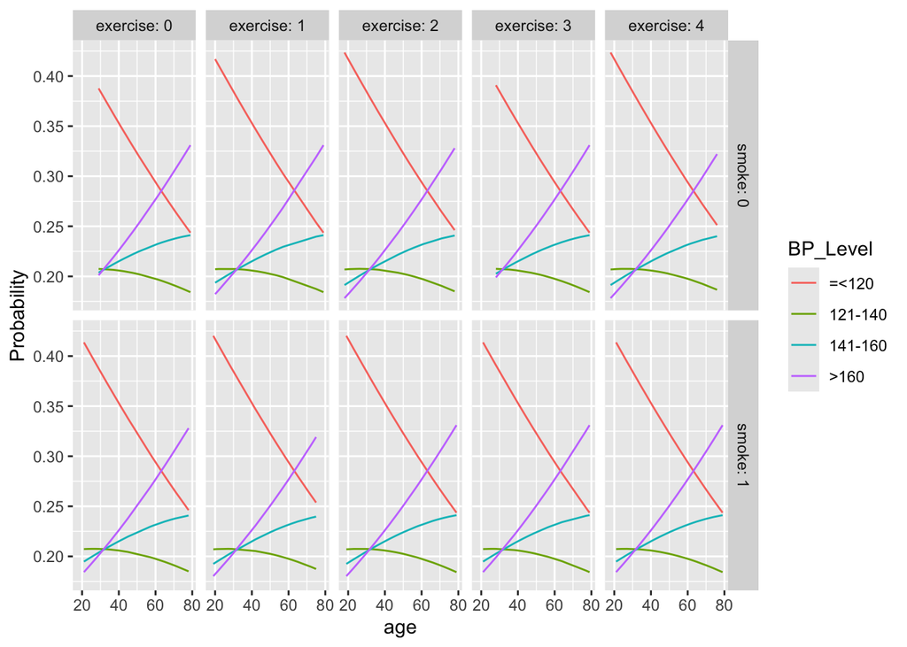

```r
ggplot(lnewdat, aes(x = age, y = Probability, colour = BP_Level)) +
  geom_line() + facet_grid(smoke ~ exercise, labeller="label_both")
```

### Manual calculation for prediction

```r
summary(o.age)
```

```
## formula: bp4 ~ age
## data:    dat.o
##
##  link  threshold nobs logLik  AIC    niter max.grad cond.H
##  logit flexible  200  -271.83 551.67 4(0)  9.04e-08 7.3e+04
##
## Coefficients:
##     Estimate Std. Error z value Pr(>|z|)
## age 0.013514   0.007463   1.811   0.0702 .
## ---
## Signif. codes:  0 '***' 0.001 '**' 0.01 '*' 0.05 '.' 0.1 ' ' 1
##
## Threshold coefficients:
##                 Estimate Std. Error z value
## =<120|121-140   -0.06519    0.38448  -0.170
## 121-140|141-160  0.77717    0.38999   1.993
## 141-160|>160     1.77128    0.40810   4.340
```

And we want to predict these data

Another way of making prediction:

To predict the probabilities of i-th falls into each category for model for a new data, we need to create a new data first. We will use `expand.grid()` to create a new data of class `data.frame`

This is the new data

```r
newData <- expand.grid(age = unique(dat.o$age))
head(newData)
```

```
##   age
## 1  32
## 2  50
## 3  22
## 4  21
## 5  63
## 6  29
```

And now the predictions

```r
lp.o.age <- predict(o.age, newdata = newData, type = 'linear.predictor')
lp.o.age
```

```
## $eta1
##         =<120      121-140   141-160     >160
## 1  -0.4976343  0.344731301 1.3388365 99999.57
## 2  -0.7408824  0.101483230 1.0955885 99999.32
## 3  -0.3624965  0.479869118 1.4739744 99999.70
## 4  -0.3489827  0.493382900 1.4874881 99999.72
## 5  -0.9165615 -0.074195932 0.9199093 99999.15
## 6  -0.4570930  0.385272646 1.3793779 99999.61
## 7  -1.1192683 -0.276902658 0.7172026 99998.95
## 8  -0.6057446  0.236621047 1.2307263 99999.46
## 9  -0.4841205  0.358245083 1.3523503 99999.58
## 10 -1.0787269 -0.236361313 0.7577439 99998.99
## 11 -1.0652131 -0.222847531 0.7712577 99999.00
## 12 -0.5246619  0.317703738 1.3118090 99999.54
## 13 -0.6327721  0.209593484 1.2036987 99999.43
```

[output cut: 112 more lines]

The coefficients for model o.age

```r
coef.o.age<- coef(o.age)
coef.o.age
```

```
##   =<120|121-140 121-140|141-160    141-160|>160             age
##     -0.06519330      0.77717232      1.77127756      0.01351378
```

```r
age_value <- 32
lp.o1.bx <- coef.o.age['age'] * age_value
```

Putting them inside the equation

```r
lp.o1.bx <- 0.01351378 * 32
lp.o1.bx <- 0.432441
```

And complete the Eq 8.25 in Hosmer

```r
logit1 <- coef.o.age['=<120|121-140'] - lp.o1.bx
logit2 <- coef.o.age['121-140|141-160'] - lp.o1.bx
logit3 <- coef.o.age['141-160|>160'] - lp.o1.bx
```

Then the probabilities are

```r
pLeq1 <- 1 / (1 + exp(-logit1))  # p(Y <= first threshold)
pLeq2 <- 1 / (1 + exp(-logit2))  # p(Y <= second threshold)
pLeq3 <- 1 / (1 + exp(-logit3))  # p(Y <= third threshold)

pLeq1 <- 1 / (1 + exp(0.4976343))  # = 0.3780968
pLeq2 <- 1 / (1 + exp(-0.3447313)) # = 0.5853394
pLeq3 <- 1 / (1 + exp(-1.3388366)) # = 0.7922986

pMat <- cbind(
  p1 = pLeq1,                   # Probability of being in the first category
  p2 = pLeq2 - pLeq1,           # Probability of being in the second category
  p3 = pLeq3 - pLeq2,           # Probability of being in the third category
  p4 = 1 - pLeq3                # Probability of being in the fourth category
)

pMat
```

```
##             p1        p2        p3        p4
## [1,] 0.3780968 0.2072426 0.2069592 0.2077014
```

Let us confirm with the prediction made by `clm()`

```r
predict(o.age, newdata = newData, type = 'prob')
```

```
## $fit
##        =<120   121-140   141-160      >160
## 1  0.3780968 0.2072426 0.2069592 0.2077015
## 2  0.3228112 0.2025378 0.2240836 0.2505674
## 3  0.4103554 0.2073616 0.1959437 0.1863393
## 4  0.4136291 0.2072739 0.1947979 0.1842990
## 5  0.2856590 0.1958005 0.2335641 0.2849764
## 6  0.3876757 0.2074685 0.2037469 0.2011089
## 7  0.2461470 0.1850663 0.2407774 0.3280093
## 8  0.3530305 0.2058503 0.2150649 0.2260543
## 9  0.3812796 0.2073360 0.2058981 0.2054864
## 10 0.2537470 0.1874362 0.2396805 0.3191363
## 11 0.2563145 0.1882031 0.2392754 0.3162071
## 12 0.3717628 0.2070018 0.2090512 0.2121843
## 13 0.3468822 0.2053252 0.2169747 0.2308179
```

[output cut: 48 more lines]

## Checking proportional odds assumption

```r
brant(polr_cr3)
```

```
## --------------------------------------------
## Test for X2  df  probability
## --------------------------------------------
## Omnibus      2.6 2   0.27
## age      2.6 2   0.27
## --------------------------------------------
##
## H0: Parallel Regression Assumption holds
```